# Proportional Odds Logit Modeling of the Ideal Shape of the Pacific Oyster

Ernest O. Chuku

2023-07-31

## Data

> Read cleaned data and store as data frame - the data is in the S3 data structure.

```r
rm(list = ls()) #clear R environment
```

```r
df_Shp <- read.csv("POLM_Ideal_Shell_Shape_data.csv")
```

> View the data structure.

```r
str(df_Shp)
```

```
## 'data.frame':    136 obs. of  4 variables:
##  $ Years  : int  25 25 25 25 30 30 30 30 12 12 ...
##  $ SCseg  : chr  "PROD" "PROD" "PROD" "PROD" ...
##  $ Shp    : chr  "A" "B" "C" "D" ...
##  $ ShpRANK: chr  "3rd" "2nd" "1st" "4th" ...
```

> Convert the outcome variable `ShpRANK` and the other categorical variables `Shp` and `SCseg` as factors.

```r
df_Shp$ShpRANK <- as.factor(df_Shp$ShpRANK)
df_Shp$Shp <- as.factor(df_Shp$Shp)
df_Shp$SCseg <- as.factor(df_Shp$SCseg)

str(df_Shp)
```

```
## 'data.frame':    136 obs. of  4 variables:
##  $ Years  : int  25 25 25 25 30 30 30 30 12 12 ...
##  $ SCseg  : Factor w/ 3 levels "PROD","PRODTRAD",..: 1 1 1 1 2 2 2 2 3 3 ...
##  $ Shp    : Factor w/ 4 levels "A","B","C","D": 1 2 3 4 1 2 3 4 1 2 ...
##  $ ShpRANK: Factor w/ 4 levels "1st","2nd","3rd",..: 3 2 1 4 2 1 3 4 3 2 ...
```

> Check the order of the outcome variable.

```r
levels(df_Shp$ShpRANK)
```

```
## [1] "1st" "2nd" "3rd" "4th"
```

> The outcome variable is ordinal. We, therefore, reorder the ranking levels from least to best. This is critical, and must be done!

```r
df_Shp$ShpRANK <- ordered(df_Shp$ShpRANK,
  levels = c("4th", "3rd", "2nd", "1st"))
levels(df_Shp$ShpRANK) # check the levels to confirm reordering
```

```
## [1] "4th" "3rd" "2nd" "1st"
```

```r
contrasts(df_Shp$Shp)
```

```
##   B C D
## A 0 0 0
## B 1 0 0
## C 0 1 0
## D 0 0 1
```

```r
contrasts(df_Shp$SCseg)
```

```
##          PRODTRAD TRAD
## PROD            0    0
## PRODTRAD        1    0
## TRAD            0    1
```

> Once the data structure is checked we are ready to apply proportional odds logit models

## Fit the Proportional Odds Logistic Regression Models

> The `polr` function from the `MASS` package is used for proportional odds regression.

```r
library(MASS)
```

### POLR Model #1

```r
fit001 <- polr(ShpRANK ~ Shp,
              Hess = TRUE,
              data = df_Shp,
              na.action = na.fail)
```

### POLR Model #2

```r
fit002 <- polr(ShpRANK ~ Shp + SCseg,
              Hess = TRUE,
              data = df_Shp,
              na.action = na.fail)
```

### POLR Model #3

```r
fit003 <- polr(ShpRANK ~ Shp + SCseg + Shp:SCseg,
              Hess = TRUE,
              data = df_Shp,
              na.action = na.fail)
```

### Perform likelihood ratio tests of Models 1-3

```r
anova(fit001, fit002, fit003)
```

```
## Likelihood ratio tests of ordinal regression models
##
## Response: ShpRANK
##                     Model Resid. df Resid. Dev   Test    Df    LR stat.
## 1                     Shp       130   276.4584
## 2             Shp + SCseg       128   276.3590 1 vs 2     2  0.09939495
## 3 Shp + SCseg + Shp:SCseg       122   242.6452 2 vs 3     6 33.71381014
##        Pr(Chi)
## 1
## 2 9.515172e-01
## 3 7.639789e-06
```

> Another model selection approach would be to specify the general model and conduct a stepwise backward and forward modelling. This is automated in R with the `step` function. Below, the `step` function also selects the model with interaction between `Shp` and `SCseg` as the best model. We are double sure about the selected model.

```r
step(fit003, test = "Chisq", direction = "both") # perform a forward and backward stepwise model, and perform likelihood ratio test at each step
```

```
## Start:  AIC=270.65
## ShpRANK ~ Shp + SCseg + Shp:SCseg
##
##             Df    AIC    LRT Pr(>Chi)
## <none>         270.64
## - Shp:SCseg  6 292.36 33.714 7.64e-06 ***
## ---
## Signif. codes:  0 '***' 0.001 '**' 0.01 '*' 0.05 '.' 0.1 ' ' 1
```

```
## Call:
## polr(formula = ShpRANK ~ Shp + SCseg + Shp:SCseg, data = df_Shp,
##     na.action = na.fail, Hess = TRUE)
##
## Coefficients:
##               ShpB               ShpC               ShpD      SCsegPRODTRAD
##          3.8521886          1.7224401         -3.5736218          2.2212293
##          SCsegTRAD ShpB:SCsegPRODTRAD ShpC:SCsegPRODTRAD ShpD:SCsegPRODTRAD
##         -1.2283644         -2.5820080         -3.7831589         -9.5279471
##     ShpB:SCsegTRAD     ShpC:SCsegTRAD     ShpD:SCsegTRAD
##         -0.3341725          2.2902447          2.9291216
##
## Intercepts:
##    4th|3rd    3rd|2nd    2nd|1st
## -1.7682632  0.8725537  2.8683852
##
## Residual Deviance: 242.6452
## AIC: 270.6452
```

```r
summary(fit003)
```

```
## Call:
## polr(formula = ShpRANK ~ Shp + SCseg + Shp:SCseg, data = df_Shp,
##     na.action = na.fail, Hess = TRUE)
##
## Coefficients:
##                      Value Std. Error t value
## ShpB                3.8522     0.8393  4.5898
## ShpC                1.7224     0.7312  2.3556
## ShpD               -3.5736     0.9660 -3.6993
## SCsegPRODTRAD       2.2212     0.8779  2.5301
## SCsegTRAD          -1.2284     0.8057 -1.5247
## ShpB:SCsegPRODTRAD -2.5820     1.2691 -2.0345
## ShpC:SCsegPRODTRAD -3.7832     1.2222 -3.0953
## ShpD:SCsegPRODTRAD -9.5279    33.6841 -0.2829
## ShpB:SCsegTRAD     -0.3342     1.1277 -0.2963
## ShpC:SCsegTRAD      2.2902     1.1026  2.0772
## ShpD:SCsegTRAD      2.9291     1.2690  2.3081
##
## Intercepts:
##         Value   Std. Error t value
## 4th|3rd -1.7683  0.5962    -2.9657
## 3rd|2nd  0.8726  0.5387     1.6198
## 2nd|1st  2.8684  0.6145     4.6676
##
## Residual Deviance: 242.6452
## AIC: 270.6452
```

> It is easier to interpret the model with p-values instead of the t-values. Calculate the p-values and append to the coefficients table

```r
# get coefficients (it's in matrix form)
coefficients <- summary(fit003)$coefficients
# calculate p-values
p_value <- (1 - pnorm(abs(coefficients[ ,"t value"]), 0, 1))*2
# bind back to coefficients
(coefficients <- cbind(coefficients, p_value))
```

```
##                         Value Std. Error    t value      p_value
## ShpB                3.8521886  0.8392972  4.5897791 4.437153e-06
## ShpC                1.7224401  0.7312147  2.3555874 1.849344e-02
## ShpD               -3.5736218  0.9660372 -3.6992588 2.162300e-04
## SCsegPRODTRAD       2.2212293  0.8779237  2.5300937 1.140321e-02
## SCsegTRAD          -1.2283644  0.8056651 -1.5246588 1.273442e-01
## ShpB:SCsegPRODTRAD -2.5820080  1.2691195 -2.0344877 4.190244e-02
## ShpC:SCsegPRODTRAD -3.7831589  1.2222185 -3.0953213 1.965998e-03
## ShpD:SCsegPRODTRAD -9.5279471 33.6840535 -0.2828622 7.772824e-01
## ShpB:SCsegTRAD     -0.3341725  1.1276970 -0.2963318 7.669767e-01
## ShpC:SCsegTRAD      2.2902447  1.1025560  2.0772139 3.778182e-02
## ShpD:SCsegTRAD      2.9291216  1.2690467  2.3081276 2.099204e-02
## 4th|3rd            -1.7682632  0.5962338 -2.9657211 3.019742e-03
## 3rd|2nd             0.8725537  0.5386852  1.6197839 1.052787e-01
## 2nd|1st             2.8683852  0.6145326  4.6675885 3.047555e-06
```

> Odds ratios are very useful for explaining the parameter estimates. We calculate the odds ratios and further calculate a less biased version recommended for categorical predictors (Baker, 2006).

```r
# calculate odds ratios
odds_ratio <- exp(coefficients[ ,"Value"]) #this is biased for categorical/dummy variables and tends to slightly overstate the effect
# for reduced bias odds ratios for dummy variables, use
odds_ratio_cat <- exp((coefficients[ ,"Value"])-((((coefficients[ ,"Std. Error"])^2)*(coefficients[ ,"Value"]))/2))
# combine with coefficient and p_value
(coefficients <- cbind(
  coefficients[ ,c("Value", "Std. Error", "p_value")],
  odds_ratio, odds_ratio_cat
))
```

```
##                         Value Std. Error      p_value   odds_ratio
## ShpB                3.8521886  0.8392972 4.437153e-06 4.709603e+01
## ShpC                1.7224401  0.7312147 1.849344e-02 5.598172e+00
## ShpD               -3.5736218  0.9660372 2.162300e-04 2.805406e-02
## SCsegPRODTRAD       2.2212293  0.8779237 1.140321e-02 9.218656e+00
## SCsegTRAD          -1.2283644  0.8056651 1.273442e-01 2.927710e-01
## ShpB:SCsegPRODTRAD -2.5820080  1.2691195 4.190244e-02 7.562200e-02
## ShpC:SCsegPRODTRAD -3.7831589  1.2222185 1.965998e-03 2.275071e-02
## ShpD:SCsegPRODTRAD -9.5279471 33.6840535 7.772824e-01 7.278890e-05
## ShpB:SCsegTRAD     -0.3341725  1.1276970 7.669767e-01 7.159303e-01
## ShpC:SCsegTRAD      2.2902447  1.1025560 3.778182e-02 9.877354e+00
## ShpD:SCsegTRAD      2.9291216  1.2690467 2.099204e-02 1.871119e+01
## 4th|3rd            -1.7682632  0.5962338 3.019742e-03 1.706291e-01
## 3rd|2nd             0.8725537  0.5386852 1.052787e-01 2.393014e+00
## 2nd|1st             2.8683852  0.6145326 3.047555e-06 1.760856e+01
##                    odds_ratio_cat
## ShpB                   12.1267016
## ShpC                    3.5323641
## ShpD                    0.1486561
## SCsegPRODTRAD           3.9165963
## SCsegTRAD               0.4361797
## ShpB:SCsegPRODTRAD      0.6049352
## ShpC:SCsegPRODTRAD      0.3838577
## ShpD:SCsegPRODTRAD            Inf
## ShpB:SCsegTRAD          0.8854239
## ShpC:SCsegTRAD          2.4551796
## ShpD:SCsegTRAD          1.7691100
## 4th|3rd                 0.2336435
## 3rd|2nd                 2.1084522
## 2nd|1st                10.2447147
```

### Estimate model fit parameters

```r
nobs(fit003) #observations
```

```
## [1] 136
```

```r
logLik(fit003) #log likelihood
```

```
## 'log Lik.' -121.3226 (df=14)
```

```r
DescTools::PseudoR2(fit003, which = "McFadden")
```

```
##  McFadden
## 0.3565017
```

```r
DescTools::PseudoR2(fit003, which = "Nagelkerke")
```

```
## Nagelkerke
##  0.6696965
```

### Perform type III test for the model

```r
library(car)
Anova(fit003, type = 3, test.statistic = "Wald")
```

```
## Analysis of Deviance Table (Type III tests)
##
## Response: ShpRANK
##           LR Chisq Df Pr(>Chisq)
## Shp         73.010  3  9.675e-16 ***
## SCseg       13.576  2   0.001127 **
## Shp:SCseg   33.714  6  7.640e-06 ***
## ---
## Signif. codes:  0 '***' 0.001 '**' 0.01 '*' 0.05 '.' 0.1 ' ' 1
```

### View the effects

> For POLM, this is a plot of the cumulative probabilities with standard errors. NB: `latent = FALSE` computes effects of POLM as individual-level probabilities and logits. `latent = TRUE` will compute effects of POLM on the scale of the latent response.

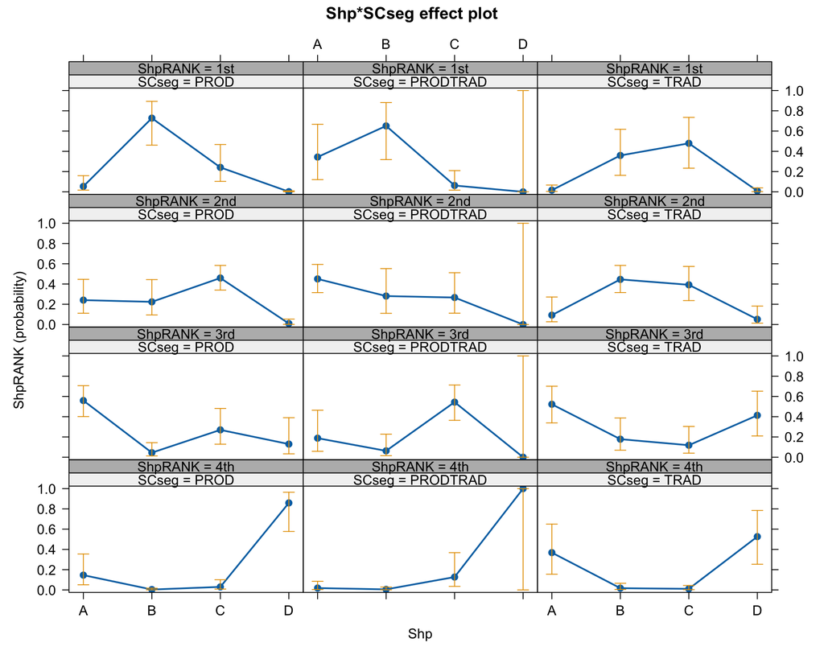

```r
library(effects)
plot(allEffects(fit003))
```

## Dealing with Interaction Term

> The estimates for the interaction term in the model summary are tricky!! Needs a bit of extra work to explain them. To make life easier, because there is enough evidence of a significant “SCseg” and “Shp” interactions (at the 10% level), “SCseg” and “Shp” are bound to form a single categorical variable “SCseg|Shp” with 12 levels. One combination is selected as the reference level.

> We concatenate the variables in the interaction term and refit the model. We go through all the procedures to include p-values, odds ratios, model fit parameters, etc.

### Model #4 (with concateated iteraction term)

```r
#concatenate string/factor variables and store as a new column
df_Shp$SCsegShp <- as.factor(paste(df_Shp$SCseg, df_Shp$Shp, sep = "|")) #combining SCseg and Shp
# fit new model
fit004 <- polr(ShpRANK ~ SCsegShp,
              Hess = TRUE,
              data = df_Shp,
              na.action = na.fail)

# get coefficients (it's in matrix form)
coefficients <- summary(fit004)$coefficients
# calculate p-values
p_value <- (1 - pnorm(abs(coefficients[ ,"t value"]), 0, 1))*2
# bind back to coefficients
coefficients <- cbind(coefficients, p_value)
# calculate odds ratios
odds_ratio <- exp(coefficients[ ,"Value"]) #this is biased for categorical/dummy variables and tends to slightly overstate the effect
# for reduced bias odds ratios for dummy variables, use
odds_ratio_cat <- exp((coefficients[ ,"Value"])-((((coefficients[ ,"Std. Error"])^2)*(coefficients[ ,"Value"]))/2))
# combine with coefficient and p_value
(coefficients <- cbind(
  coefficients[ ,c("Value", "Std. Error", "p_value")],
  odds_ratio, odds_ratio_cat
))
```

```
##                          Value   Std. Error      p_value   odds_ratio
## SCsegShpPROD|B       3.8529154 8.394535e-01 4.436915e-06 4.713027e+01
## SCsegShpPROD|C       1.7222207 7.312632e-01 1.851617e-02 5.596944e+00
## SCsegShpPROD|D      -3.5746080 9.661356e-01 2.156821e-04 2.802641e-02
## SCsegShpPRODTRAD|A   2.2228374 8.780081e-01 1.135168e-02 9.233493e+00
## SCsegShpPRODTRAD|B   3.4892793 9.265279e-01 1.659014e-04 3.276233e+01
## SCsegShpPRODTRAD|C   0.1614240 8.132103e-01 8.426522e-01 1.175183e+00
## SCsegShpPRODTRAD|D -18.6497856 6.209867e-07 0.000000e+00 7.952452e-09
## SCsegShpTRAD|A      -1.2310688 8.058386e-01 1.265904e-01 2.919803e-01
## SCsegShpTRAD|B       2.2902429 7.747017e-01 3.113640e-03 9.877337e+00
## SCsegShpTRAD|C       2.7853228 8.088090e-01 5.737403e-04 1.620505e+01
## SCsegShpTRAD|D      -1.8729783 8.361491e-01 2.509059e-02 1.536653e-01
## 4th|3rd             -1.7694306 5.964528e-01 3.011230e-03 1.704300e-01
## 3rd|2nd              0.8724687 5.387551e-01 1.053577e-01 2.392811e+00
## 2nd|1st              2.8680757 6.146121e-01 3.064020e-06 1.760311e+01
##                    odds_ratio_cat
## SCsegShpPROD|B       1.212628e+01
## SCsegShpPROD|C       3.531581e+00
## SCsegShpPROD|D       1.486284e-01
## SCsegShpPRODTRAD|A   3.919824e+00
## SCsegShpPRODTRAD|B   7.327150e+00
## SCsegShpPRODTRAD|C   1.114102e+00
## SCsegShpPRODTRAD|D   7.952452e-09
## SCsegShpTRAD|A       4.354586e-01
## SCsegShpTRAD|B       4.967833e+00
## SCsegShpTRAD|C       6.516144e+00
## SCsegShpTRAD|D       2.957513e-01
## 4th|3rd              2.334732e-01
## 3rd|2nd              2.108230e+00
## 2nd|1st              1.024071e+01
```

```r
nobs(fit004)
```

```
## [1] 136
```

```r
logLik(fit004)
```

```
## 'log Lik.' -121.3217 (df=14)
```

```r
DescTools::PseudoR2(fit004, which = "McFadden")
```

```
##  McFadden
## 0.3565065
```

```r
DescTools::PseudoR2(fit004, which = "Nagelkerke")
```

```
## Nagelkerke
##  0.6697017
```

```r
Anova(fit004, type = 3, test.statistic = "Wald")
```

```
## Analysis of Deviance Table (Type III tests)
##
## Response: ShpRANK
##          LR Chisq Df Pr(>Chisq)
## SCsegShp   134.43 11  < 2.2e-16 ***
## ---
## Signif. codes:  0 '***' 0.001 '**' 0.01 '*' 0.05 '.' 0.1 ' ' 1
```

> Now the estimates are much easier to comprehend. You can observe that Models #3 and #4 are the same!

> Let’s view the effects plot for Model #4. For POLR, this a plot of the cumulative probabilities with standard errors. NB: `latent = FALSE` computes effects of POLR model as individual-level probabilities and logits. `latent = TRUE` will compute effects of POLR model on the scale of the latent response.

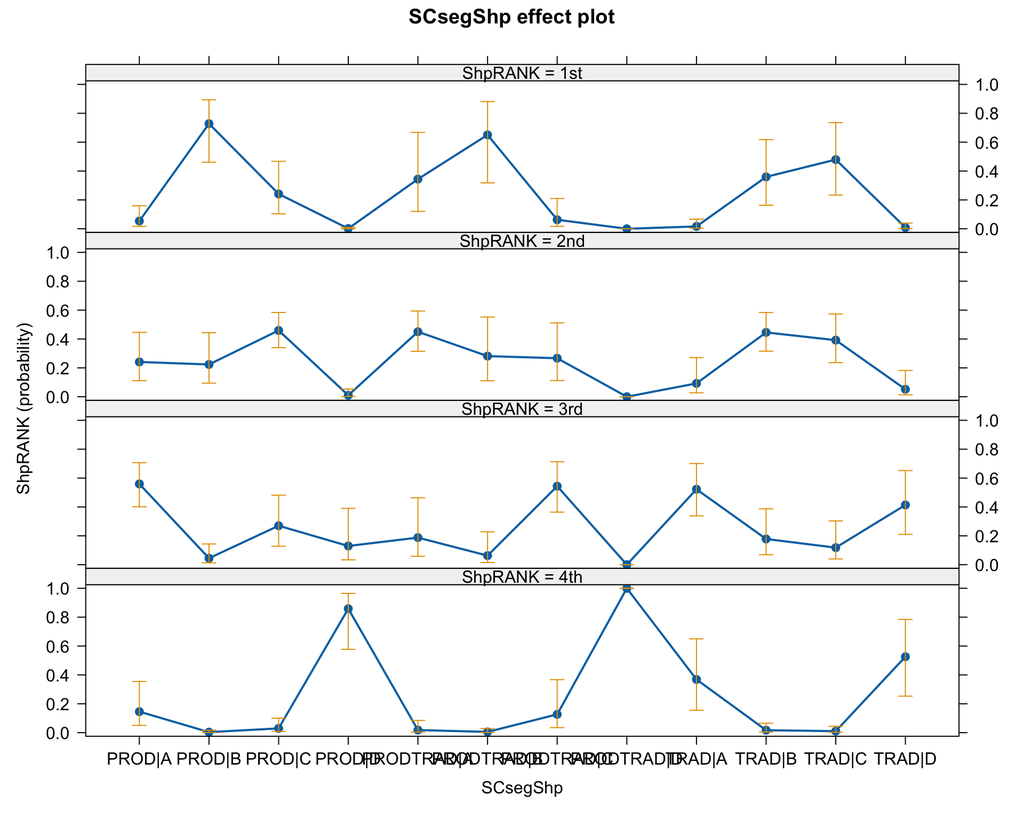

```r
plot(allEffects((fit004), latent = FALSE))
```

> The probability estimates (effects) among the ranks is still the same as for Model #3.

Multiple comparisons of model coefficients

```r
library(emmeans)
#get estimated means coefficients of factor levels for a categorical predictor and store
em <- emmeans(fit004, "SCsegShp")
#get multiple comparisons OR contrasts among the factor levels
#contrast(em, "pairwise", adjust = "Tukey")
#save multiple comparisons as a dataframe
df_EstCOMP <- data.frame(contrast(em, "pairwise", adjust = "Tukey"), check.names = FALSE, stringsAsFactors = FALSE)
# calculate odds ratios
df_EstCOMP$OR <- round((exp(df_EstCOMP[ ,"estimate"])-1)*100)
# for reduced bias odds ratios for the differences in parameter estimates, use
df_EstCOMP$OR_cat <- round(((exp((df_EstCOMP[ ,"estimate"])-((((df_EstCOMP[ ,"SE"])^2)*(df_EstCOMP[ ,"estimate"]))/2)))-1)*100)
#reorder such that contrasts significant p-values will be on top
df_EstCOMP_ord <- df_EstCOMP[order(df_EstCOMP$p.value),]
# View the reordered contrasts
head(df_EstCOMP_ord)
```

```
##                   contrast estimate           SE  df      z.ratio p.value
## 7      PROD|A - PRODTRAD|D 18.64979 6.209867e-07 Inf 3.003250e+07       0
## 17     PROD|B - PRODTRAD|D 22.50270 8.394539e-01 Inf 2.680636e+01       0
## 26     PROD|C - PRODTRAD|D 20.37201 7.312636e-01 Inf 2.785864e+01       0
## 34     PROD|D - PRODTRAD|D 15.07518 9.661360e-01 Inf 1.560358e+01       0
## 41 PRODTRAD|A - PRODTRAD|D 20.87262 8.780085e-01 Inf 2.377269e+01       0
## 47 PRODTRAD|B - PRODTRAD|D 22.13906 9.265282e-01 Inf 2.389465e+01       0
##              OR      OR_cat
## 7   12574738617 12574738617
## 17 592650808934   213519193
## 26  70380107278   303304239
## 34    352424697      309991
## 41 116108760656    37223466
## 47 411977716155    30754320
```

Select specific contrasts of model coefficients from `df_EstCOMP_ord` for comparison

```r
df_EstCOMP_ord[is.element(df_EstCOMP_ord$contrast,
                          c('PROD|A - PROD|B',
                            'PROD|A - PROD|C',
                            'PROD|A - PROD|D',
                            'PROD|B - PROD|C',
                            'PROD|B - PROD|D',
                            'PROD|C - PROD|D')),]
```

```
##           contrast  estimate        SE  df   z.ratio      p.value     OR OR_cat
## 13 PROD|B - PROD|D  7.427523 1.0920411 Inf  6.801505 6.829433e-10 168064   1906
## 22 PROD|C - PROD|D  5.296829 1.0066446 Inf  5.261865 9.257402e-06  19870   1264
## 1  PROD|A - PROD|B -3.852915 0.8394535 Inf -4.589790 2.776108e-04    -98    -92
## 3  PROD|A - PROD|D  3.574608 0.9661356 Inf  3.699903 1.162546e-02   3468    573
## 12 PROD|B - PROD|C  2.130695 0.7744069 Inf  2.751389 2.013152e-01    742    345
## 2  PROD|A - PROD|C -1.722221 0.7312632 Inf -2.355131 4.370924e-01    -82    -72
```

Calculating specific, odds ratios and odds for the contrasts NORMAL (run the code as is)

```r
library(dplyr)

#Subset data
df_EstCOMP_select <- df_EstCOMP %>% filter(contrast == "PROD|B - PROD|D")
# for reduced bias odds ratios for the differences in parameter estimates, use
ORcat <- exp((df_EstCOMP_select$estimate)-((((df_EstCOMP_select$SE)^2)*(df_EstCOMP_select$estimate))/2))

#ORcat <- exp((df_EstCOMP_select$estimate)-(((df_EstCOMP_select$SE)^2)/2))
Odds_cat <- (ORcat-1)*100
ORnorm <- exp(df_EstCOMP_select$estimate)
Odds_norm <- (ORnorm-1)*100

ORcat #bias-reduced odds ratio; not appropriate for small odds ratios
```

```
## [1] 20.0587
```

```r
Odds_cat #bias-reduced odds;
```

```
## [1] 1905.87
```

```r
ORnorm #normal odds ratio; biased for categorical variables
```

```
## [1] 1681.638
```

```r
Odds_norm #normal odds
```

```
## [1] 168063.8
```

Calculating specific odds for reverse differences that do not show above; REVERSE negative to positive (use absolute `abs` to convert negative estimate to positive)

```r
#Subset data
df_EstCOMP_select <- df_EstCOMP %>% filter(contrast == "PROD|A - PROD|B") #reversing to "PROD|B - PROD|A"
# for reduced bias odds ratios for the differences in parameter estimates, use
ORcat <- exp((abs(df_EstCOMP_select$estimate))-((((df_EstCOMP_select$SE)^2)*(abs(df_EstCOMP_select$estimate)))/2))
# the bias-reduced odds; not appropriate for small odds ratios
Odds_cat <- (ORcat-1)*100

#for normal odds ratio
ORnorm <- exp((abs(df_EstCOMP_select$estimate)))
#Normal odds
Odds_norm <- (ORnorm-1)*100

#view the results
ORcat
```

```
## [1] 12.12628
```

```r
Odds_cat
```

```
## [1] 1112.628
```

```r
ORnorm
```

```
## [1] 47.13027
```

```r
Odds_norm
```

```
## [1] 4613.027
```

Calculating specific odds for reverse differences that do not show above REVERSE positive to negative (multiply the estimate by `-1` to negate it)

```r
#Subset data
df_EstCOMP_select <- df_EstCOMP %>% filter(contrast == "PROD|B - PROD|D") #reversing to "PROD|D - PROD|B"
#Reverse estimate positive to negative
REVestimate <- (-1)*(df_EstCOMP_select$estimate)
# for reduced bias odds ratios for the differences in parameter estimates, use
ORcat <- exp(REVestimate-((((df_EstCOMP_select$SE)^2)*(REVestimate))/2))

Odds_cat <- (ORcat-1)*100
ORnorm <- exp(REVestimate)
Odds_norm <- (ORnorm-1)*100

#view the results
ORcat
```

```
## [1] 0.04985368
```

```r
Odds_cat
```

```
## [1] -95.01463
```

```r
ORnorm
```

```
## [1] 0.0005946584
```

```r
Odds_norm
```

```
## [1] -99.94053
```

## Estimating predicted probabilities

```r
model_best <- fit003
```

> How does the data frame look like at this point?

```r
head(df_Shp)
```

```
##   Years    SCseg Shp ShpRANK   SCsegShp
## 1    25     PROD   A     3rd     PROD|A
## 2    25     PROD   B     2nd     PROD|B
## 3    25     PROD   C     1st     PROD|C
## 4    25     PROD   D     4th     PROD|D
## 5    30 PRODTRAD   A     2nd PRODTRAD|A
## 6    30 PRODTRAD   B     1st PRODTRAD|B
```

> Let’s select on the columns for the predictions, i.e., the variables used in the model.

```r
# only keep what is used in the analysis
df_ShpRANKselect <- dplyr::select(df_Shp, Shp, SCseg, ShpRANK)
levels(df_ShpRANKselect$ShpRANK) # check the levels of ShpRANK again
```

```
## [1] "4th" "3rd" "2nd" "1st"
```

```r
head(df_ShpRANKselect)
```

```
##   Shp    SCseg ShpRANK
## 1   A     PROD     3rd
## 2   B     PROD     2nd
## 3   C     PROD     1st
## 4   D     PROD     4th
## 5   A PRODTRAD     2nd
## 6   B PRODTRAD     1st
```

```r
# add the predicted probabilities to the data frame
df_ShpRANKselect <- cbind(df_ShpRANKselect, predict(model_best, type = "probs"))

head(df_ShpRANKselect) # show the probabilities
```

```
##   Shp    SCseg ShpRANK         4th        3rd         2nd         1st
## 1   A     PROD     3rd 0.145758456 0.55951833 0.240984502 0.053738708
## 2   B     PROD     2nd 0.003609925 0.04474450 0.223783324 0.727862251
## 3   C     PROD     1st 0.029577911 0.26987877 0.459312804 0.241230518
## 4   D     PROD     4th 0.858799983 0.12961254 0.009996802 0.001590672
## 5   A PRODTRAD     2nd 0.018172745 0.18791423 0.450282283 0.343630737
## 6   B PRODTRAD     1st 0.005170135 0.06276455 0.281159160 0.650906156
```

> We tidy up the predicted probabilities for plotting.

```r
library(tidyverse)
# convert the data frame to long format for plotting
df_plot <- gather(df_ShpRANKselect, key = Predicted, value = Probability, 4:7) #edit column numbers to suit your data frame

head(df_plot) # examine the data
```

```
##   Shp    SCseg ShpRANK Predicted Probability
## 1   A     PROD     3rd       4th 0.145758456
## 2   B     PROD     2nd       4th 0.003609925
## 3   C     PROD     1st       4th 0.029577911
## 4   D     PROD     4th       4th 0.858799983
## 5   A PRODTRAD     2nd       4th 0.018172745
## 6   B PRODTRAD     1st       4th 0.005170135
```

> Remove duplicate rows - rows with repeated probabilities

```r
# only keep the columns we need and remove duplicate rows
df_plot <- df_plot %>% dplyr::select(Shp, SCseg, Predicted, Probability) %>%
  unique()
# ensure Predicted column is ordered
df_plot$Predicted <- ordered(df_plot$Predicted,
  levels = c("4th", "3rd", "2nd", "1st"))
# rearrange the rows
df_plot <- df_plot %>%  arrange(Shp, SCseg, Predicted)

df_plot # look at the whole data frame
```

```
##    Shp    SCseg Predicted  Probability
## 1    A     PROD       4th 1.457585e-01
## 2    A     PROD       3rd 5.595183e-01
## 3    A     PROD       2nd 2.409845e-01
## 4    A     PROD       1st 5.373871e-02
## 5    A PRODTRAD       4th 1.817274e-02
## 6    A PRODTRAD       3rd 1.879142e-01
## 7    A PRODTRAD       2nd 4.502823e-01
## 8    A PRODTRAD       1st 3.436307e-01
## 9    A     TRAD       4th 3.682111e-01
## 10   A     TRAD       3rd 5.227812e-01
## 11   A     TRAD       2nd 9.265291e-02
## 12   A     TRAD       1st 1.635471e-02
## 13   B     PROD       4th 3.609925e-03
## 14   B     PROD       3rd 4.474450e-02
```

[output cut: 34 more lines]

## Plot stack column chart of predicted probabilities for the model

```r
library(ggplot2)
library(ggthemes)     # provides additional ggplot themes
library(RColorBrewer) # provides additional colors
library(cowplot)      # place multiple ggplots side by side
```

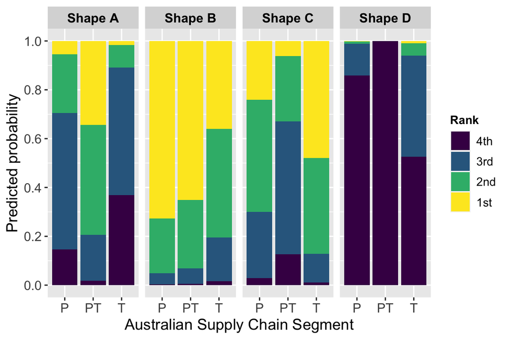

```r
df_plot2 <- df_plot
levels(df_plot2$Shp)[levels(df_plot2$Shp)=="A"] <- "Shape A"
levels(df_plot2$Shp)[levels(df_plot2$Shp)=="B"] <- "Shape B"
levels(df_plot2$Shp)[levels(df_plot2$Shp)=="C"] <- "Shape C"
levels(df_plot2$Shp)[levels(df_plot2$Shp)=="D"] <- "Shape D"

plot_ColRANK <- ggplot(df_plot2, aes(x = SCseg, y = Probability, fill = Predicted)) +
  geom_col(position = position_stack(reverse = TRUE)) +
  scale_y_continuous(breaks = c(0.0,0.2,0.4,0.6,0.8,1.0)) +
  facet_wrap(~ Shp, ncol=6) +
  labs(x = "Australian Supply Chain Segment", y = "Predicted probability", fill = "Rank") +
  scale_x_discrete(labels=c("PROD" = "P", "PRODTRAD" = "PT", "TRAD" = "T")) +
theme(legend.title = element_text(size=10, face="bold")) +
  theme(legend.text = element_text(size=10))

plot_ColRANKfin <- plot_ColRANK +
  theme(axis.title.x = element_text(size=13)) +
  theme(axis.title.y = element_text(size=13)) +
  theme(axis.text.x = element_text(size=11)) +
  theme(axis.text.y = element_text(size=11)) +
  theme(strip.text.x = element_text(size = 11, color = "black", face = "bold"))

plot_ColRANKfin
```

## Predict mean categorical rank outcomes for specific traits of in each state

```r
# Get levels of each categorical predictor using the terms in the model
LEVELS1 <- levels(df_ShpRANKselect$Shp)
LEVELS2 <- levels(df_ShpRANKselect$SCseg)
```

```r
# Create a data.frame to store the predictions
df_predRANKS <- data.frame(
  Shp   = rep(LEVELS1, length(LEVELS2)),
  SCseg = rep(LEVELS2, each=length(LEVELS1))
)
```

```r
# Add the predictions
df_predRANKS$predRANKS <- predict(model_best, df_predRANKS)

# View the predicted ranks
df_predRANKS
```

```
##    Shp    SCseg predRANKS
## 1    A     PROD       3rd
## 2    B     PROD       1st
## 3    C     PROD       2nd
## 4    D     PROD       4th
## 5    A PRODTRAD       2nd
## 6    B PRODTRAD       1st
## 7    C PRODTRAD       3rd
## 8    D PRODTRAD       4th
## 9    A     TRAD       3rd
## 10   B     TRAD       2nd
## 11   C     TRAD       1st
## 12   D     TRAD       4th
```

```r
#sort by SCseg and predRANKS in descending order
df_predRANKS$predRANKS <- ordered(df_predRANKS$predRANKS)
df_predRANKS_ord <- df_predRANKS[order(df_predRANKS$SCseg, df_predRANKS$predRANKS, decreasing = TRUE),]
# View the ordered predicted ranks
df_predRANKS_ord
```

```
##    Shp    SCseg predRANKS
## 11   C     TRAD       1st
## 10   B     TRAD       2nd
## 9    A     TRAD       3rd
## 12   D     TRAD       4th
## 6    B PRODTRAD       1st
## 5    A PRODTRAD       2nd
## 7    C PRODTRAD       3rd
## 8    D PRODTRAD       4th
## 2    B     PROD       1st
## 3    C     PROD       2nd
## 1    A     PROD       3rd
## 4    D     PROD       4th
```

## Testing the Proportionality Assumption

### Brant-Wald Test

```r
brant::brant(fit001)
```

```
## --------------------------------------------
## Test for X2  df  probability
## --------------------------------------------
## Omnibus      4.49    6   0.61
## ShpB     2.83    2   0.24
## ShpC     0.7 2   0.7
## ShpD     0.77    2   0.68
## --------------------------------------------
##
## H0: Parallel Regression Assumption holds
```

```r
brant::brant(fit002)
```

```
## --------------------------------------------
## Test for X2  df  probability
## --------------------------------------------
## Omnibus      4.49    10  0.92
## ShpB     2.83    2   0.24
## ShpC     0.7 2   0.7
## ShpD     0.77    2   0.68
## SCsegPRODTRAD    0   2   1
## SCsegTRAD    0   2   1
## --------------------------------------------
##
## H0: Parallel Regression Assumption holds
```

```r
brant::brant(fit003)
```

```
## ----------------------------------------------------
## Test for     X2  df  probability
## ----------------------------------------------------
## Omnibus          5.55    22  1
## ShpB         0   2   1
## ShpC         0.23    2   0.89
## ShpD         0   2   1
## SCsegPRODTRAD        0   2   1
## SCsegTRAD        1.01    2   0.6
## ShpB:SCsegPRODTRAD   0   2   1
## ShpC:SCsegPRODTRAD   0   2   1
## ShpD:SCsegPRODTRAD   0   2   1
## ShpB:SCsegTRAD       0   2   1
## ShpC:SCsegTRAD       0.03    2   0.99
## ShpD:SCsegTRAD       0   2   1
## ----------------------------------------------------
##
## H0: Parallel Regression Assumption holds
```

### Graphical Method [Manually Checking the proportional odds assumption (see detailed explanations at https://stats.oarc.ucla.edu/r/dae/ordinal-logistic-regression/)]

```r
library(Hmisc)

sf <- function(y) {
  c('Y>=1' = qlogis(mean(y >= 1)),
    'Y>=2' = qlogis(mean(y >= 2)),
    'Y>=3' = qlogis(mean(y >= 3)),
    'Y>=4' = qlogis(mean(y >= 4)))
}

(s <- with(df_Shp, summary(as.numeric(ShpRANK) ~ Shp + SCseg + Shp:SCseg, fun=sf)))
```

```
## as.numeric(ShpRANK)      N= 136
##
## +-------+--------+---+----+---------+----------+----------+
## |       |        |  N|Y>=1|     Y>=2|      Y>=3|      Y>=4|
## +-------+--------+---+----+---------+----------+----------+
## |    Shp|       A| 34| Inf| 1.349927|-0.6061358|-1.7578579|
## |       |       B| 34| Inf|      Inf| 2.7725887| 0.2363888|
## |       |       C| 34| Inf|      Inf| 0.6061358|-1.0216512|
## |       |       D| 34| Inf|-1.349927|-2.7725887|-3.4965076|
## +-------+--------+---+----+---------+----------+----------+
## |  SCseg|    PROD| 56| Inf| 1.098612| 0.0000000|-1.0986123|
## |       |PRODTRAD| 32| Inf| 1.098612| 0.0000000|-1.0986123|
## |       |    TRAD| 48| Inf| 1.098612| 0.0000000|-1.0986123|
## +-------+--------+---+----+---------+----------+----------+
## |Overall|        |136| Inf| 1.098612| 0.0000000|-1.0986123|
## +-------+--------+---+----+---------+----------+----------+
```

```r
levels(df_Shp$ShpRANK)
```

```
## [1] "4th" "3rd" "2nd" "1st"
```

```r
levels(df_Shp$SCseg)
```

```
## [1] "PROD"     "PRODTRAD" "TRAD"
```

```r
summary(glm(I(as.numeric(ShpRANK) >= 2) ~ Shp, family="binomial", data = df_Shp))
```

```
##
## Call:
## glm(formula = I(as.numeric(ShpRANK) >= 2) ~ Shp, family = "binomial",
##     data = df_Shp)
##
## Coefficients:
##              Estimate Std. Error z value Pr(>|z|)
## (Intercept)    1.3499     0.4241   3.183  0.00146 **
## ShpB          19.2161  3040.7334   0.006  0.99496
## ShpC          19.2161  3040.7334   0.006  0.99496
## ShpD          -2.6999     0.5998  -4.501 6.76e-06 ***
## ---
## Signif. codes:  0 '***' 0.001 '**' 0.01 '*' 0.05 '.' 0.1 ' ' 1
##
## (Dispersion parameter for binomial family taken to be 1)
##
##     Null deviance: 152.955  on 135  degrees of freedom
## Residual deviance:  69.149  on 132  degrees of freedom
## AIC: 77.149
##
## Number of Fisher Scoring iterations: 19
```

```r
summary(glm(I(as.numeric(ShpRANK) >= 3) ~ Shp, family="binomial", data = df_Shp))
```

```
##
## Call:
## glm(formula = I(as.numeric(ShpRANK) >= 3) ~ Shp, family = "binomial",
##     data = df_Shp)
##
## Coefficients:
##             Estimate Std. Error z value Pr(>|z|)
## (Intercept)  -0.6061     0.3589  -1.689  0.09122 .
## ShpB          3.3787     0.8124   4.159  3.2e-05 ***
## ShpC          1.2123     0.5075   2.389  0.01691 *
## ShpD         -2.1665     0.8124  -2.667  0.00766 **
## ---
## Signif. codes:  0 '***' 0.001 '**' 0.01 '*' 0.05 '.' 0.1 ' ' 1
##
## (Dispersion parameter for binomial family taken to be 1)
##
##     Null deviance: 188.54  on 135  degrees of freedom
## Residual deviance: 118.72  on 132  degrees of freedom
## AIC: 126.72
##
## Number of Fisher Scoring iterations: 5
```

```r
summary(glm(I(as.numeric(ShpRANK) >= 4) ~ Shp, family="binomial", data = df_Shp))
```

```
##
## Call:
## glm(formula = I(as.numeric(ShpRANK) >= 4) ~ Shp, family = "binomial",
##     data = df_Shp)
##
## Coefficients:
##             Estimate Std. Error z value Pr(>|z|)
## (Intercept)  -1.7579     0.4842  -3.630 0.000283 ***
## ShpB          1.9942     0.5948   3.353 0.000800 ***
## ShpC          0.7362     0.6210   1.186 0.235784
## ShpD         -1.7386     1.1246  -1.546 0.122109
## ---
## Signif. codes:  0 '***' 0.001 '**' 0.01 '*' 0.05 '.' 0.1 ' ' 1
##
## (Dispersion parameter for binomial family taken to be 1)
##
##     Null deviance: 152.96  on 135  degrees of freedom
## Residual deviance: 123.38  on 132  degrees of freedom
## AIC: 131.38
##
## Number of Fisher Scoring iterations: 6
```

```r
s[, 5] <- s[, 5] - s[, 4]
s[, 4] <- s[, 4] - s[, 4]

s # print
```

```
## as.numeric(ShpRANK)      N= 136
##
## +-------+--------+---+----+---------+----+----------+
## |       |        |  N|Y>=1|     Y>=2|Y>=3|      Y>=4|
## +-------+--------+---+----+---------+----+----------+
## |    Shp|       A| 34| Inf| 1.349927|   0|-1.1517221|
## |       |       B| 34| Inf|      Inf|   0|-2.5361999|
## |       |       C| 34| Inf|      Inf|   0|-1.6277871|
## |       |       D| 34| Inf|-1.349927|   0|-0.7239188|
## +-------+--------+---+----+---------+----+----------+
## |  SCseg|    PROD| 56| Inf| 1.098612|   0|-1.0986123|
## |       |PRODTRAD| 32| Inf| 1.098612|   0|-1.0986123|
## |       |    TRAD| 48| Inf| 1.098612|   0|-1.0986123|
## +-------+--------+---+----+---------+----+----------+
## |Overall|        |136| Inf| 1.098612|   0|-1.0986123|
## +-------+--------+---+----+---------+----+----------+
```

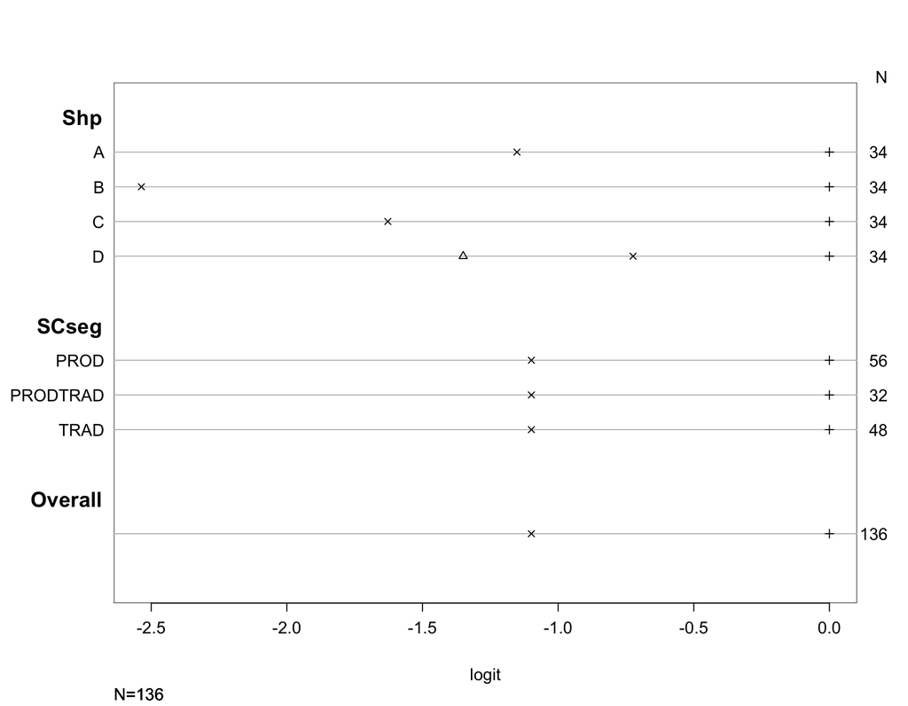

```r
plot(s, which=1:4, pch=1:4, xlab='logit', main=' ', xlim=range(s[,4:5]))
```